# Workshop 6: GenAI‑Assisted Design

Author

The Graph Courses

# Overview

In this session you will try two small but practical GenAI design workflows:

1. **Create a promotional flyer** for our course showcase using **Canva** for image generation and final editing.

(You can share this flyer on your website or social media with colleagues and friends to get them to come to the showcase.)

2. (**Optional challenge**) **Turn a research paper into a visual abstract** using **Claude** and **HTML** or **SVG**.

# Task 1 – AI Flyer for the Final Presentation

**Account Required**: You’ll need a free **Canva** account. Sign up at **canva.com** if you haven’t already.

### 1-A Sign up for Canva Pro Trial

1. Go to [canva.com](https://www.canva.com/) and sign up for an account or log in.
2. Visit the Canva pricing page at [canva.com/pricing](https://www.canva.com/pricing/).
3. Switch from “Yearly” to “Monthly” billing.

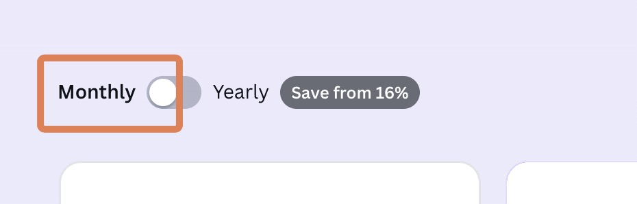

Canva pricing page, monthly option

[figure not shown]

Canva start free trial button

5. You will need to enter your credit card details to start the trial, but you won’t be charged if you cancel before the trial period ends.
6. Once you have started the trial, go to your account settings and find “Billing & Teams” or visit https://www.canva.com/settings/billing-and-teams and click “Cancel plan”.

[figure not shown]

Canva cancel plan button

7. If you have previously used your free trial, you can create a new account with a different email address, or ask an instructor for assistance.

### 1-B Generate Flyer Image in Canva

1. Navigate to the Canva home page by clicking the home icon or by visiting [canva.com](https://www.canva.com/).
2. In the main prompt box, select ‘Canva AI’, select ‘Image’, and set the aspect ratio to 3:4 for a more poster-like format.

[figure not shown]

Canva prompt box options

3. In the prompt box, describe the image you want to create. You can copy and paste the recommended prompt below, or write your own. For color inspiration, check out [coolors.co](https://coolors.co/). Feel free to experiment with other aspects of the prompt.

[output not shown]

[output cut: 30 more lines]

[output not shown]

Create a rich, accurate, and visually appealing SVG code-based visual abstract of the following paper:

[Paper Title] [Paper Abstract]

[output not shown]

Create a rich, accurate, and visually appealing HTML visual abstract of the following paper:

After Claude generates the initial design, you can ask it to make specific changes or improvements to refine the visual abstract. “For example, make the subtitle larger, italics and use a different color/font.”

If you are happy with the design, you can take a screenshot and then upload it to your assignment submission area on the course page. The page should allow multiple submissions. (After you upload one file, simply repeat the process to upload another file.)

### 2-C Edit and Finalize

If you want to make some custom edits, you can do so in the following ways.

**If you chose SVG:**

1. In Claude, click on the dropdown arrow at the top right of the SVG preview
2. Click on “Download SVG”

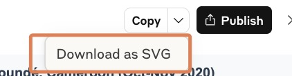

Download SVG in Claude

3. Open PowerPoint and drag the downloaded SVG file into a slide
4. To make the elements editable, you need to ungroup/convert the SVG:
- **For Mac users**: Right-click on the image, click on “Group”, then “Ungroup”. You may need to repeat this process several times until there’s nothing left to ungroup.

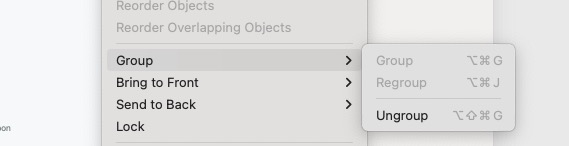

Ungroup in Powerpoint for Mac

- **For Windows users**: Right-click on the image and click on “Convert to shape”.

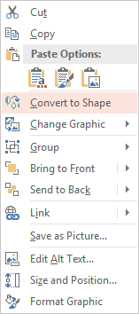

Ungroup in Powerpoint for Windows

5. Some of the elements may have become malformed during the conversion process. You may therefore need to make some edits to individual elements
6. When finished, export as a PDF or take a screenshot of your slide

**If you chose HTML:**

1. Copy the HTML code from Claude’s response
2. Go to **https://app.grapesjs.com/studio** (a free visual HTML editor) and open the editor
3. Paste the HTML code into the editor
4. Use the visual interface to edit the design as needed
5. For detailed guidance on editing with GrapesJS, watch this video:

[video not shown]

6. When you’re satisfied with your design, take a screenshot of the final result.